# Lab01

variables

```r
phone <- 80
transportation <- 20
groceries <- 527
gym <- 10
rent <- 1500
other <- 83
```

total expense

```r
total <- phone + transportation + groceries + gym + rent + other
total
```

```
## [1] 2220
```

semester expenses

```r
total * 5
```

```
## [1] 11100
```

year expenses

```r
total * 10
```

```
## [1] 22200
```

your vector expenses

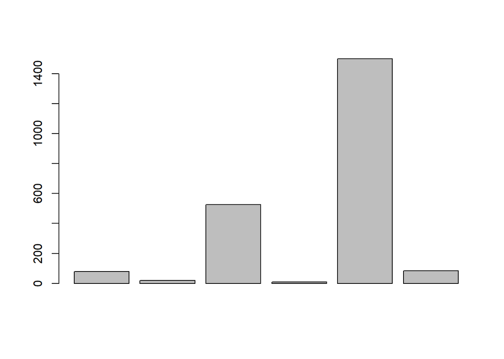

```r
expense <- c(phone, transportation, groceries, gym, rent, other)
barplot(expense)
```

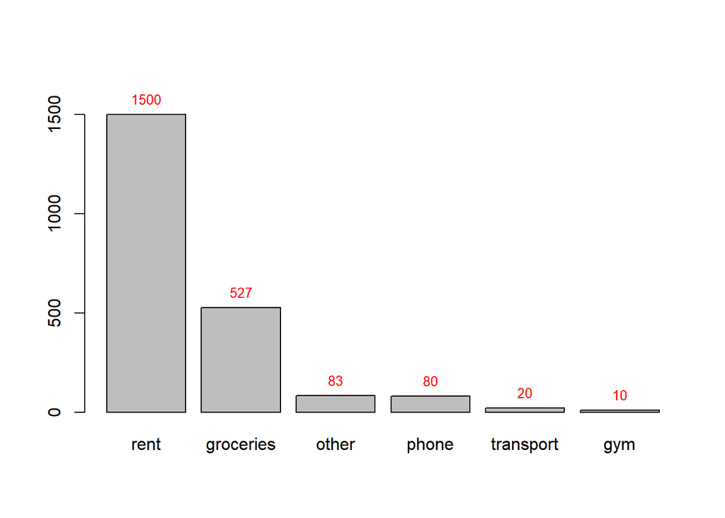

```r
expense <- sort(expense, decreasing = TRUE)

## Find a range of y's that'll leave sufficient space above the tallest bar
ylim <- c(0, 1.1*max(expense))
## Plot, and store x-coordinates of bars in xx
expense_plot <- barplot(expense, ylim = ylim, names.arg = c("rent", "groceries",                            "other", "phone", "transport", "gym"))
## Add text at top of bars
text(x = expense_plot, y = expense, label = expense, pos = 3, cex = 0.8, col = "red")
```

# Pythagoras formula

```r
a <- 3
b <- 4
c <- sqrt(a ^ 2 + b ^ 2)
c
```

```
## [1] 5
```

# Binomial Formula

Let’s consider a simple example. A fair coin is tossed 5 times. What is the probability of getting exactly 2 heads?

Create the objects n, k, and p for the number of trials, the number of success, and the probability of success, respectively.

```r
n <- 5
k <- 2
p <- 1/2
```

Use factorial() to compute the number of combinations “n choose k”

```r
n_choose_k <- factorial(n)/(factorial(k) * factorial(n - k))
```

Apply the binomial formula, using factorial(), to calculate the probability of getting exactly 2 heads out of 5 tosses.

```r
n_choose_k * (p ^ k) * (1 - p) ^ (n - k)
```

```
## [1] 0.3125
```

Recalculate the same probability but now using choose() (instead of factorial())

```r
choose(n, k) * (p ^ k) * (1 - p) ^ (n - k)
```

```
## [1] 0.3125
```

Consider rolling a fair die 10 times. What is the probability of getting exactly 3 sixes?

```r
n2 <- 10
k2 <- 3
p2 <- 1/6
choose(n2, k2) * (p2 ^ k2) * (1 - p2) ^ (n2 - k2)
```

```
## [1] 0.1550454
```

Now look for help documentation (e.g. help.search() or ??) using the keyword binomial: binomial.

```r
??binomial
```

```
## starting httpd help server ... done
```

You should get a list of topics related with the searched term binomial.

Choose the one related with the Binomial Distribution, which is part of the R package stats (i.e. stats::Binomial).

```r
dbinom(k, n, p)
```

```
## [1] 0.3125
```

```r
dbinom(k2, n2, p2)
```

```
## [1] 0.1550454
```

How would you modify the previous binomial function to calculate the same probability (2 heads in 5 tosses) of a biased coin with a chance of heads of 35%?

```r
dbinom(k, n, p = 0.35)
```

```
## [1] 0.3364156
```

Finally, obtain the probability of getting more than 3 heads in 5 tosses with a biased coin of 35% chance of heads.

```r
dbinom(4, 5, 0.35) + dbinom(5, 5, 0.35)
```

```
## [1] 0.0540225
```

# Installing Packages

Install packages “stringr”, “RColorBrewer”, and “XML”

```r
install.packages(c("stringr", "RColorBrewer", "XML"), repos = "http://cran.us.r-project.org")
```

Calculate: 3x2^2+ 4x+8 when x=2

```r
x <- 2
3 * 2 ^ 2 + 4 * x + 8
```

```
## [1] 28
```

```r
x <- -3:3
3 * 2 ^ 2 + 4 * x + 8
```

```
## [1]  8 12 16 20 24 28 32
```